# The *Apple Inc.* Case: Digital Perspectives on Brand Communication

SKOD32: Strategic Brand Communication 2026

nils.holmberg@iko.lu.se

## Course Literature

[figure not shown]

Grębosz-Krawczyk & Siuda (2026)

[figure not shown]

Elliott et al. (2015)

[figure not shown]

Hatch & Schultz (2008)

## Reading and study guide (1)

| Chapter | Book Pages | Concepts and Models |
| --- | --- | --- |
| 1 Brand concept | 33–39 | Brand functions; perceived risk; functional and emotional roles; country-of-origin effect |
| 2 Identity and positioning | 46–58 | Identity–image; Upshaw’s brand essence; Aaker’s core and extended identity; Kapferer’s prism; consistency vs flexibility |
| 3 Brand and consumer | 81–105 | Perception and categorization; semiotics and storytelling; memory and learning; attitudes; motivation; personality; social identity and tribes |
| 4 Integrated communication | 111–115 | 4P to 4C; two-way communication and noise; integrated communication; AIDA |
| 5 Strong digital brands | 166–184 | UX and brand experience; KPIs; AI hyper-personalization; metaverse; virtual influencers; platformization; ethics and privacy |

## Reading and study guide (2)

- **Tool**: [Gemini Notebook](https://notebook.google.com/) as a study partner
- **Sources**: add the book pages from guide (1)
- **Summarize**: ask for key concepts per chapter
- **Practice**: generate quiz questions and flashcards
- **Verify**: check every answer against the book

[figure not shown]

Gemini Notebook, https://notebook.google.com/

## Case Part 1: Individual Preparation

## Theory Map

| Chapter | Concepts and Models | Helps You Investigate |
| --- | --- | --- |
| 1 Brand concept | Brand functions; functional, emotional, symbolic roles | Which functions to emphasize? |
| 2 Identity and positioning | Brand essence; Aaker; Kapferer’s prism; identity–image | What stays stable, what adapts? |
| 4 Integrated communication | 4P to 4C; AIDA; content matrix; communities | How do messages and channels work together? |
| 5 Strong digital brands | UX; KPIs; hyper-personalization; algorithmic branding | How to use AI responsibly and measure trust? |

## Preparation Questions

1. Which 2–3 theories best explain the tension between relevance, privacy, and trust?
2. Where might Apple’s identity diverge from consumers’ image after the rollout?
3. Which functional, emotional, and symbolic benefits reinforce or contradict each other?
4. How do technical and perceived privacy differ, and why does it matter?
5. Which two pieces of evidence support a recommendation, and what is one limitation?

## Models in Digital Brand Management (ch. 2)

## Upshaw: Brand Essence

- **Brand Essence**: purpose and values at the center
- **Positioning and Personality**: inner identity ring
- **Digital Amplifiers**: social media, influencers, SEO, algorithms
- **Co-Creation**: identity shaped with consumers
- **Coherence**: essence consistent across platforms

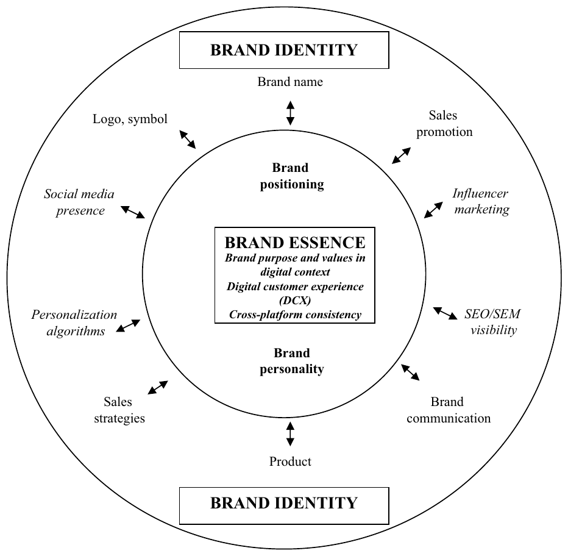

Figure 2.1, Ch. 2 (Grębosz-Krawczyk & Siuda, 2026, p. 49)

## Apple: Brand Essence

- **Essence**: technology made human and personal
- **Positioning**: premium, integrated ecosystem
- **Personality**: simple, creative, confident
- **Amplifiers**: keynotes, retail, personalization
- **Risk**: AI hype can blur the essence

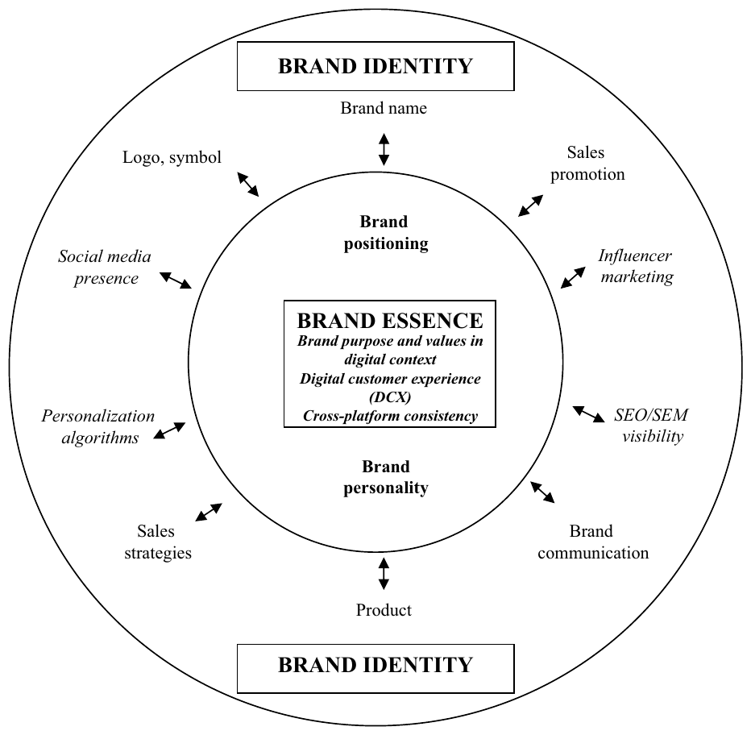

Figure 2.1, Ch. 2 (Grębosz-Krawczyk & Siuda, 2026, p. 49)

## Kapferer: Identity Prism

- **Sender**: physique and personality
- **Recipient**: reflection and self-image
- **Connection**: relationship and culture
- **Externalization**: physique, relationship, reflection
- **Digital**: reviews, CRM, brand voice, user personas

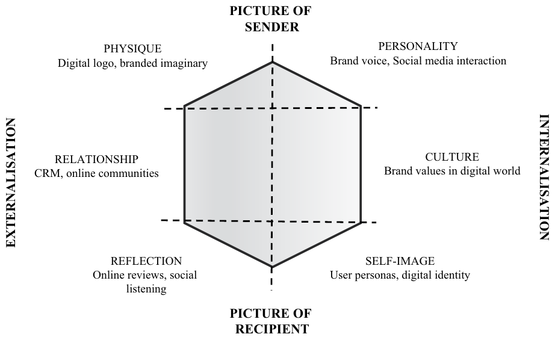

Figure 2.2, Ch. 2 (Grębosz-Krawczyk & Siuda, 2026, p. 55)

## Apple: Identity Prism

- **Physique**: design, devices, interface
- **Personality**: confident, minimalist voice
- **Culture**: privacy, creativity, “Think different”
- **Relationship**: trusted partner, not observer
- **Self-Image**: “I create with it”

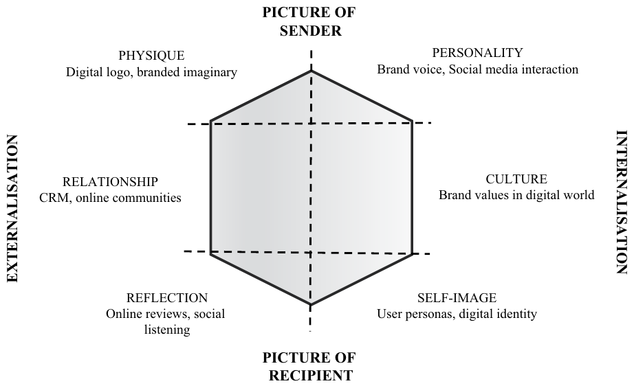

Figure 2.2, Ch. 2 (Grębosz-Krawczyk & Siuda, 2026, p. 55)

## Positioning Process

- **Start**: target market and competitor analysis
- **Identity**: describe identity, select differentiators
- **Proposal**: benchmark with positioning maps
- **Evaluation**: test with consumer research
- **Monitoring**: continuous tracking and repositioning

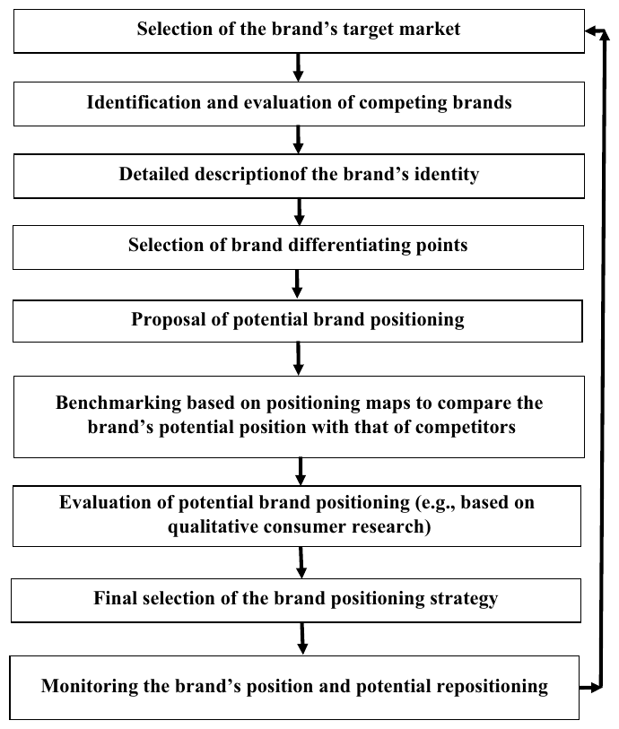

Figure 2.3, Ch. 2 (Grębosz-Krawczyk & Siuda, 2026, p. 71)

## Apple: Positioning AI

- **Target**: users aged 18–34, mixed AI attitudes
- **Competitors**: Google, Samsung, OpenAI
- **Differentiator**: privacy and integration
- **Testing**: pilot ads as positioning research
- **Monitoring**: repositioning after uneven rollout

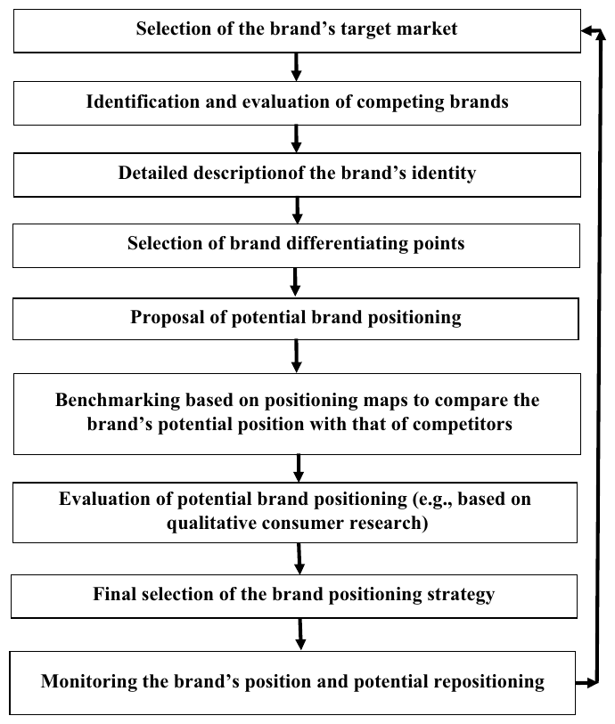

Figure 2.3, Ch. 2 (Grębosz-Krawczyk & Siuda, 2026, p. 71)

## Case Part 2: Group Discussion

## Session 1: Challenges and Alternatives

| Time | Activity | Content |
| --- | --- | --- |
| 0–8 min | Activate the preparation | Discussion of theory choices and brief feedback on Part 1 |
| 8–15 min | Hand out and read Part 2 | Groups highlight facts, assumptions, and the complication |
| 15–27 min | Diagnosis and theory | Formulate the problem and apply at least one model from Chapter 2 |
| 27–40 min | Compare alternatives | Test at least three alternatives against clear criteria |
| 40–45 min | Preliminary decision | Each group states its direction and the most difficult goal conflict |

## The Decision

- **Your Role**: Nordic strategy team advising Apple
- **Launch**: campaign in six weeks, consumers aged 18–34
- **Audience**: high AI awareness, uneven understanding
- **Mixed Attitudes**: some want practical tools, others distrust AI claims
- **Objective**: device consideration and feature trial

[figure not shown]

Siri asks permission before using ChatGPT (Apple Newsroom, 2024)

## Three Proposals

| Direction | Core Idea | Advantage | Risk |
| --- | --- | --- | --- |
| A Personal and private | “Personal for you. Private by design.” | Functional and emotional value, reinforces privacy | Defensive or too abstract |
| B AI personalized | Many message versions adapted by data | Relevance, learning, conversion | Intrusive, fragments the brand |
| C Participation based | Users and creators show outcomes, Apple curates | Concrete, credible, co-creation | Quality, disclosure, copyright, control |

## The Pilot Ad

- **The Message**: “Your iPhone knows when work is overwhelming…”
- **The Data**: context and engagement signals, not private messages
- **The Paradox**: it does not use what it appears to know
- **The Result**: highest click-through rate of all versions
- **The Reaction**: several participants found it intrusive

[figure not shown]

Image Playground (Apple Newsroom, 2024)

## Session 2: Present Recommendations

| Time | Activity | Content |
| --- | --- | --- |
| 0–18 min | Develop the recommendation | Positioning, campaign idea, touchpoints, and the role and limits of AI |
| 18–27 min | Measurement and stress test | KPIs, risk, countermeasure, and remaining uncertainty |
| 27–40 min | Short presentations | About 2.5 minutes per group and one critical question from another table |
| 40–45 min | Exam connection | Individually: which theory was used, what did it reveal, and what could it not determine? |

**Listen for**: theory application • evidence • comparison of alternatives • strategic context • handling of goal conflicts

## Group Task

1. State the central problem in one sentence, separate from its symptoms
2. Define the brand essence to protect, using a Chapter 2 model
3. Compare three alternatives on coherence, value, trust, feasibility, impact
4. Choose audience, position, campaign idea, and lead benefit
5. Connect three touchpoints from attention to action
6. Decide where AI is used and where human judgment decides
7. Select 4–6 KPIs, including trust and behavior
8. Name the main risk, one mitigation, and one open uncertainty

## Short Presentation

| Part | Content | Time |
| --- | --- | --- |
| Diagnosis | Problem and theoretical interpretation | 45 sec |
| Recommendation | Direction, position, and touchpoints | 60 sec |
| Boundaries | AI limits, KPIs, risk, and uncertainty | 45 sec |
| Challenge | One critical question from another table | After |

## Models in Digital Brand Management (ch. 4)

## From 4P to 4C

- **Product → Needs**: customer solution first
- **Price → Cost**: total cost to customer
- **Place → Convenience**: easy access
- **Promotion → Communication**: two-way dialogue
- **Shift**: from marketer view to customer view

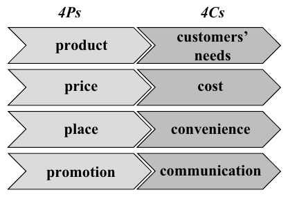

Figure 4.1, Ch. 4 (Grębosz-Krawczyk & Siuda, 2026, p. 111)

## Apple: 4C Perspective

- **Needs**: everyday help with writing and tasks
- **Cost**: device price plus data and privacy
- **Convenience**: built into familiar apps
- **Communication**: demos and trials, not claims
- **Insight**: privacy is part of customer cost

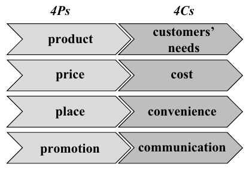

Figure 4.1, Ch. 4 (Grębosz-Krawczyk & Siuda, 2026, p. 111)

## Two-Way Communication

- **Encoding**: brand identity becomes a message
- **Decoding**: receiver forms brand image
- **Noise**: external and internal interference
- **Feedback**: reception and reaction loop back
- **Risk**: image differs from intended identity

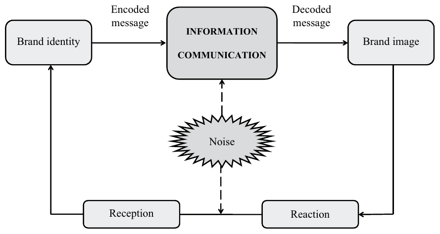

Figure 4.2, Ch. 4 (Grębosz-Krawczyk & Siuda, 2026, p. 114)

## Apple: Message and Noise

- **Encoded**: personal and private AI
- **External Noise**: competing AI hype
- **Internal Noise**: delayed features, mixed claims
- **Decoded**: “it knows too much”
- **Feedback**: social listening and reactions

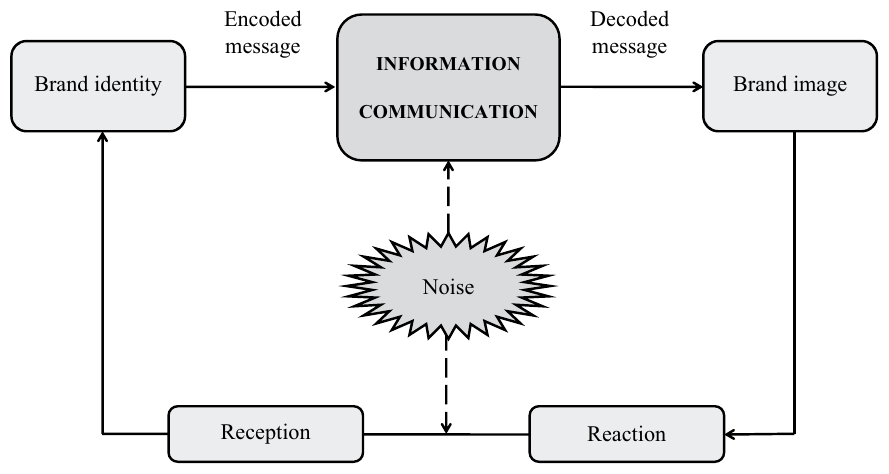

Figure 4.2, Ch. 4 (Grębosz-Krawczyk & Siuda, 2026, p. 114)

## AIDA Model

- **Awareness**: cognitive stage
- **Interest**: affective stage begins
- **Desire**: emotional engagement
- **Action**: behavioral stage, purchase
- **Extensions**: AIDAR and AIDCAS add retention and trust

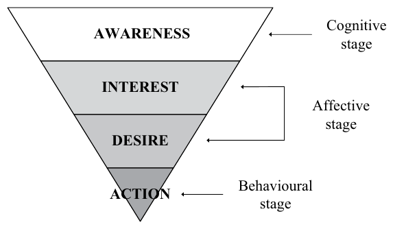

Figure 4.3, Ch. 4 (Grębosz-Krawczyk & Siuda, 2026, p. 115)

## Apple: AIDA Journey

- **Awareness**: creator demos on social media
- **Interest**: concrete everyday use cases
- **Desire**: hands-on trial in store
- **Action**: guided first use on device
- **Retention**: delivered experience builds trust

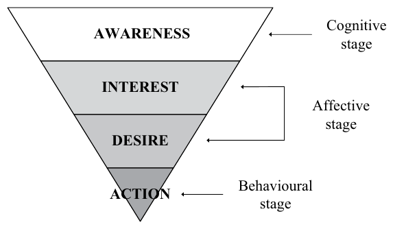

Figure 4.3, Ch. 4 (Grębosz-Krawczyk & Siuda, 2026, p. 115)

## Content Marketing Matrix

- **Axes**: emotional–rational, awareness–purchase
- **Entertain**: quizzes, competitions, virals
- **Inspire**: forums, endorsements, reviews
- **Educate**: infographics, reports, whitepapers
- **Convince**: demos, guides, calculators

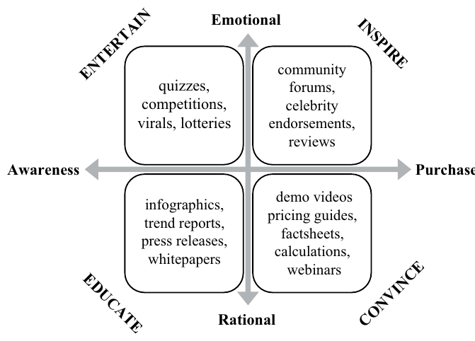

Figure 4.5, Ch. 4 (Grębosz-Krawczyk & Siuda, 2026, p. 134)

## Apple: Content Matrix

- **Entertain**: playful Image Playground content
- **Inspire**: creator stories and reviews
- **Educate**: privacy explainers
- **Convince**: feature demos and trials
- **Balance**: emotional and rational content

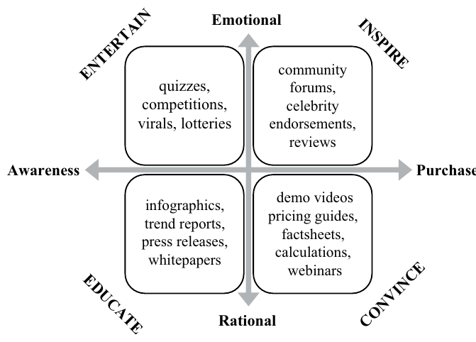

Figure 4.5, Ch. 4 (Grębosz-Krawczyk & Siuda, 2026, p. 134)

## References

Elliott, R. H., Rosenbaum-Elliott, R., Percy, L., & Pervan, S. (2015). *Strategic brand management*. Oxford University Press, USA.

Grębosz-Krawczyk, M., & Siuda, D. (2026). *Digital brand management: Understanding consumers and communication in the digital age*. Routledge.

Hatch, M. J., & Schultz, M. (2008). *Taking brand initiative: How companies can align strategy, culture, and identity through corporate branding*. John Wiley & Sons.